# report_Tregubova

In economics the Hedonic Pricing Method that assumes the possibility to explain price of product by the combination of its characteristics is often applied to predict property value. That sounds logical because properties do have big number of specific factors that influence on price such as number of rooms, space, technical equipement and furniture that we pay attention when agree on the price. At the same time, location of property also explain price variation: access to retail, transport, number of playgrounds all may increase or decrease the price depending on its values..

Given this, the aim of the research is to estimate the ability of internal and geospatial factors explain the price of apartments in Moscow. By other words, the paper seeks to understand how well Hedonic pricing model fits Russian capital Housing market.

The research consisted of three steps: 1. At first, we identify the strength of relationships between property explaining variables such as number of rooms and year of construction and price of purchase. 2. Next, we analyze external variables related to presence and remoteness of facilities in a district , pursuing to add value to increase prediction ability of internal factors. 3. OLS regression is built and assumptions are justified to prove the quality of model

#Dataset. Summarative statistic

The analysis is performed on data of the biggest Russian bank Sberbank about mortgage deals made through the bank during the period 2011 till 2015. Dataset was openly available within Kaggle competition held in 2016. For the paper purposes only ‘train’ dataset was used because there is no intention to check the model stability over the time but to point out the variables the most influence the property pricing in Moscow.

Dataset contains 30471 observations and 292 variables, among which by default the program detected 185 integer variables, 16 factors and 91 numeric variables. However during the further analysis we will transform several ordinal variables, mistakenly recognised as integers, into factors. Also, we do not have intention to analyze every valuable but only those of them that describe property or important characteristics of its location.

```
## [1] "size of dataset:"
```

```
## [1] 30471   292
```

```
## [1] "types of columns:"
```

```
##
##  factor integer numeric
##      16     185      91
```

All features represent two big groups, one of each is a range of property parametres such as area or floor and another is external factors such as number of cafes or public transport accessability. At each stage we will work separately with variables from one of this groups.

Each observaion represesents the unique purchase transaction made in period 2011-2015 that could be an acquisition of a property either for investing or living there. In our data the type of purchase is presented in product_type variable.

```
## [1]  TRUE FALSE
```

```
## [1] 0
```

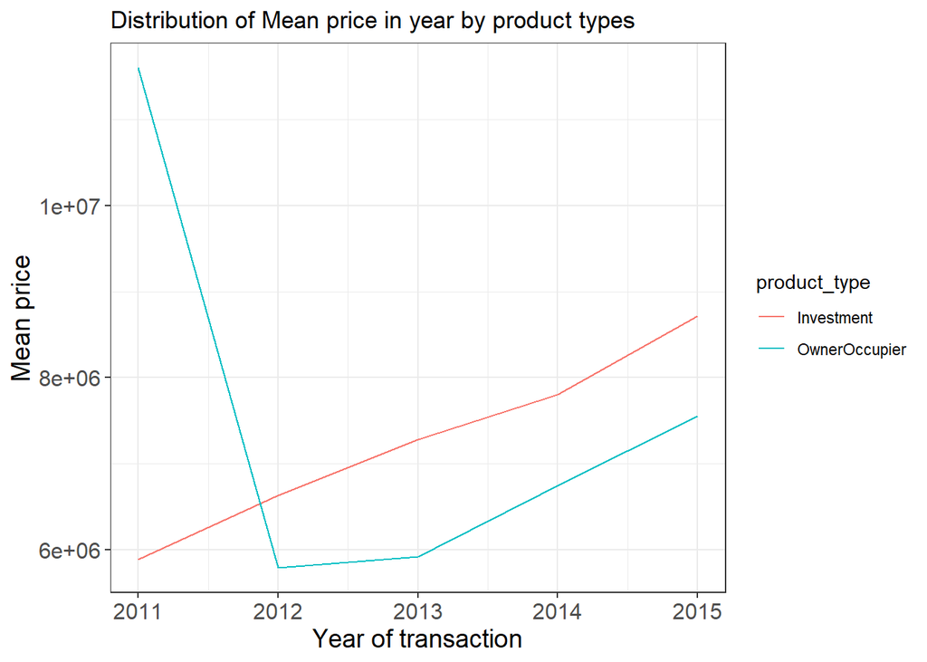

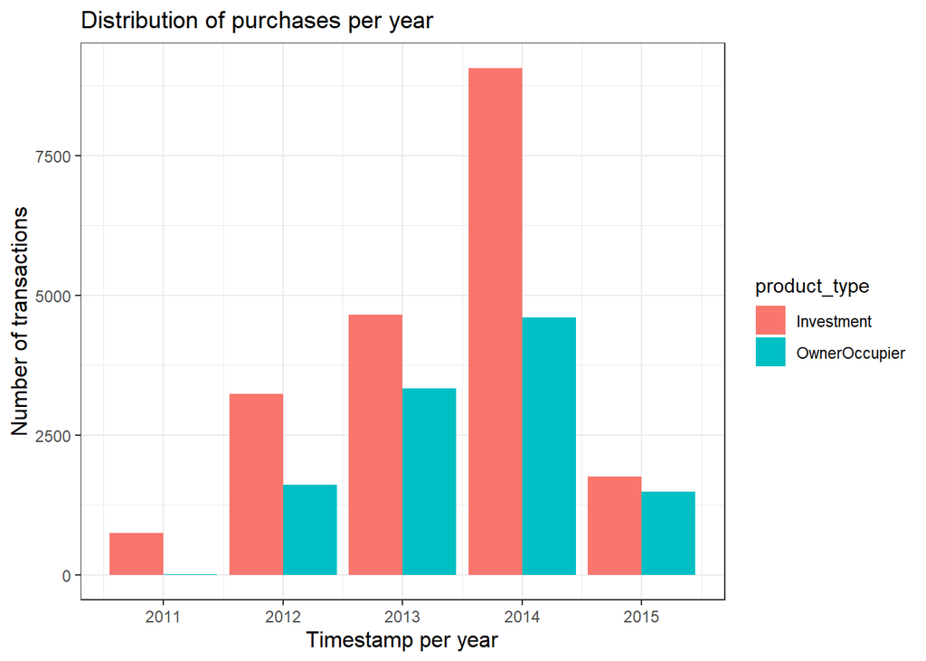

Two things can be seen from these diagrams. First, product types have different levels of price where properties sold by owners are cheaper - we ignore the mean price of secondary housing in 2011 because of the very small amount of data available for this year. In order to realize if this difference is statistically significant we perform Welch Two Sample t-test where null hypothesis is property prices of for investment and occupying purpose are the same. Whilst the normality of distribution of analyzed variable is a main condition of running t-test, we take a logarithm of price, whose distribution is slightly left-skewed.

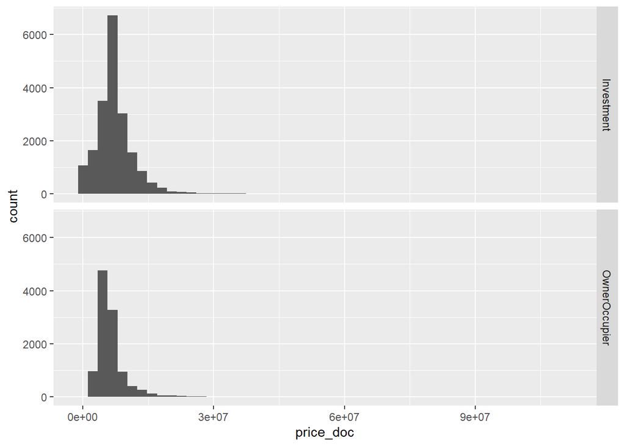

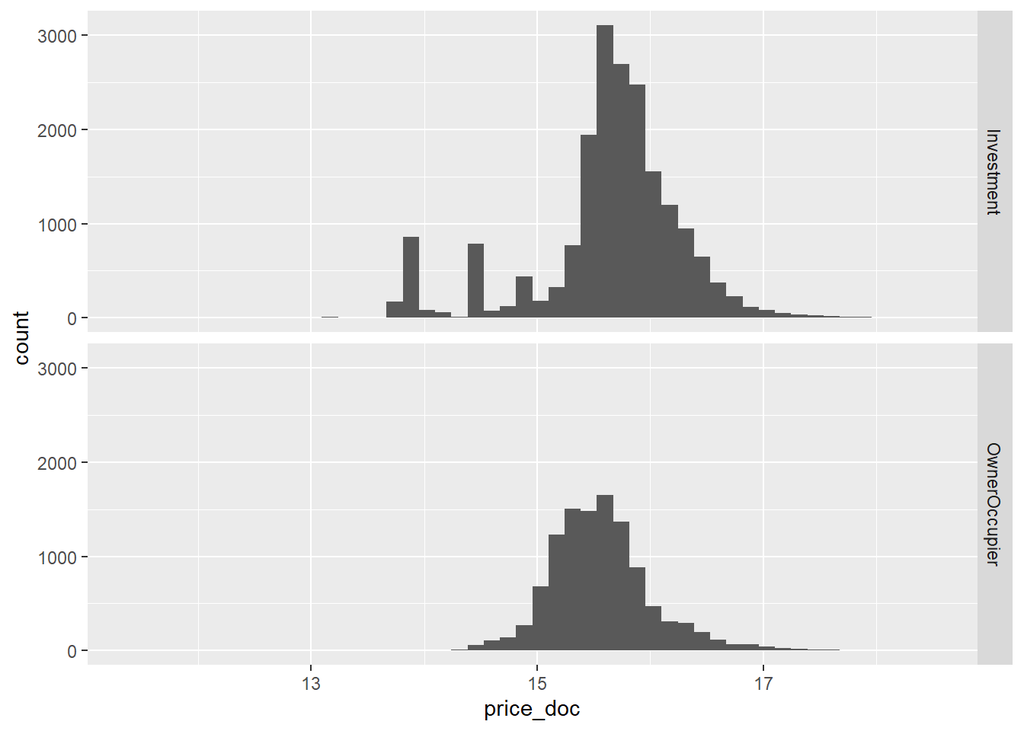

Results of t-test where p-value is less than threshold 0.05 tell us to reject null hypothesis. Prices between both product types are different, so two models, each for one product type may give better results

```
##
##  Welch Two Sample t-test
##
## data:  data_house %>% mutate(price_doc = log(price_doc)) %>% filter(product_type ==  and data_house %>% mutate(price_doc = log(price_doc)) %>% filter(product_type ==     "Investment") %>% select(price_doc) and     "OwnerOccupier") %>% select(price_doc)
## t = 11.11, df = 29664, p-value < 2.2e-16
## alternative hypothesis: true difference in means is not equal to 0
## 95 percent confidence interval:
##  0.05921905 0.08458979
## sample estimates:
## mean of x mean of y
##  15.63549  15.56359
```

The second finding from the diagram of price distribution over purchase years is a nearly-linear growth of price during the period in both product types. It means the steady historic growth of price may diminish the impact of other variables that are more important for us. To solve this issue and make price independable, we transform it by using linear equitation coefficients given from linear model.

```
##
## Call:
## lm(formula = data_invest$mean_price ~ data_invest$year)
##
## Residuals:
##       1       2       3       4       5
##  -13338   54509   16356 -142889   85361
##
## Coefficients:
##                    Estimate Std. Error t value Pr(>|t|)
## (Intercept)      -1.370e+09  6.483e+07  -21.13 0.000232 ***
## data_invest$year  6.841e+05  3.221e+04   21.24 0.000228 ***
## ---
## Signif. codes:  0 '***' 0.001 '**' 0.01 '*' 0.05 '.' 0.1 ' ' 1
##
## Residual standard error: 101900 on 3 degrees of freedom
## Multiple R-squared:  0.9934, Adjusted R-squared:  0.9912
## F-statistic: 451.1 on 1 and 3 DF,  p-value: 0.0002283
```

```
##
## Call:
## lm(formula = data_own$mean_price ~ data_own$year)
##
## Residuals:
##       1       2       3       4
##  205901 -278316  -61070  133485
##
## Coefficients:
##                 Estimate Std. Error t value Pr(>|t|)
## (Intercept)   -1.225e+09  2.394e+08  -5.116   0.0361 *
## data_own$year  6.116e+05  1.189e+05   5.143   0.0358 *
## ---
## Signif. codes:  0 '***' 0.001 '**' 0.01 '*' 0.05 '.' 0.1 ' ' 1
##
## Residual standard error: 265900 on 2 degrees of freedom
## Multiple R-squared:  0.9297, Adjusted R-squared:  0.8946
## F-statistic: 26.45 on 1 and 2 DF,  p-value: 0.03579
```

When we know coefficients and have a very high value or R-squared that confirms linearity between mean price and year, we can translate prices into basis using the formula: (price-intercept)/(year*slope)

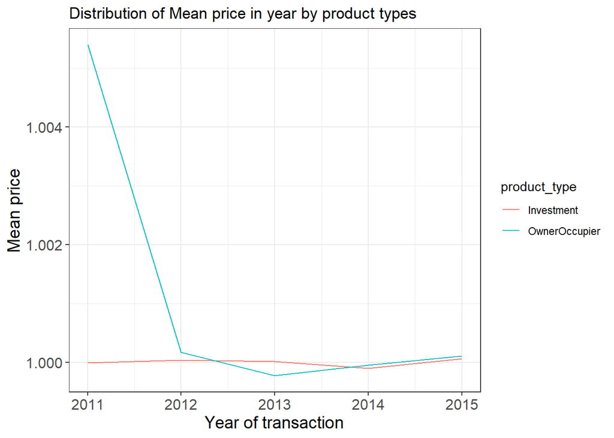

From this time we will use price_new as a target variable.

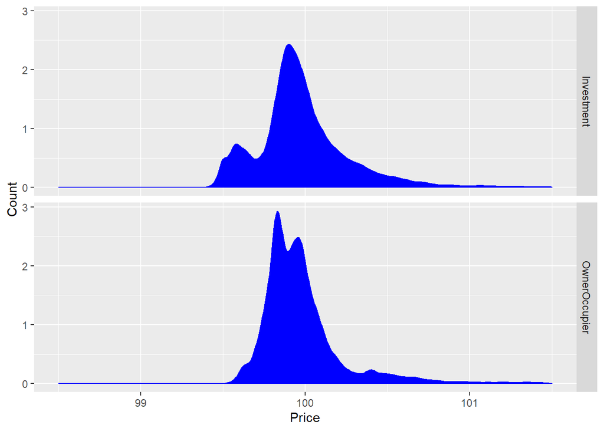

Next, data should be cleaned. We assume that it contains errors and missings that may worsen prediction quality. The most suitable way is to do it together with bivariate association analysis.

#Analysis of explanatory variables describing property

Following the plan we start from analysing and transforming variables describing apartments themselves.

First, we will test the ability of descibing property variables to explain its price and to make it done these variables should be cleaned as well as bivariate assocciations between all factors should be analysed.

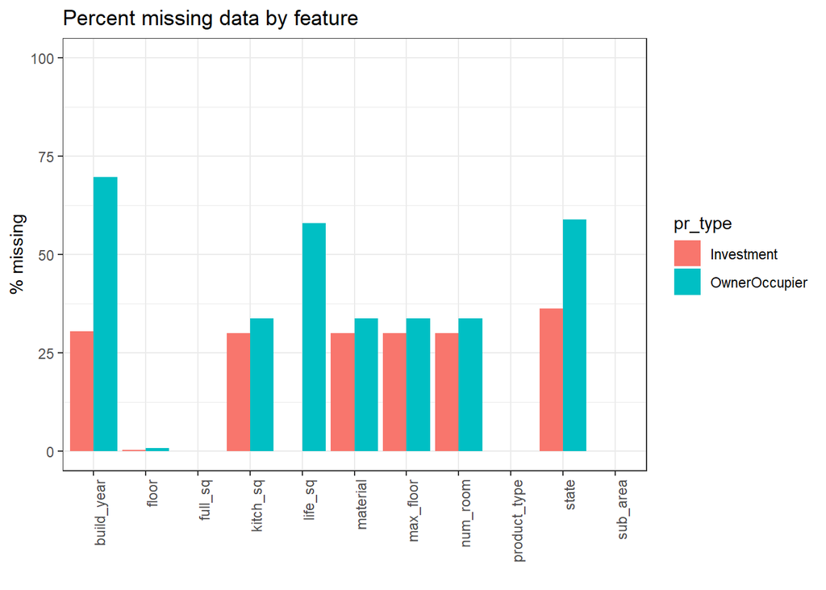

Build_year variable has over 25% and about 70% of missings in new and secondary housing, respectively, so they should be replaced rather than dropped.Also there are abnormal values in build_year like 0, 215 or 4965 that should be replaced as well. Moreover, purchase types have different range of years constructions.Investments were made in buildings erected between 1950th and 2015 with the peak in seventies, whereas buildings with OwnerOccupier product type are all new, though the most of information is unavailable.

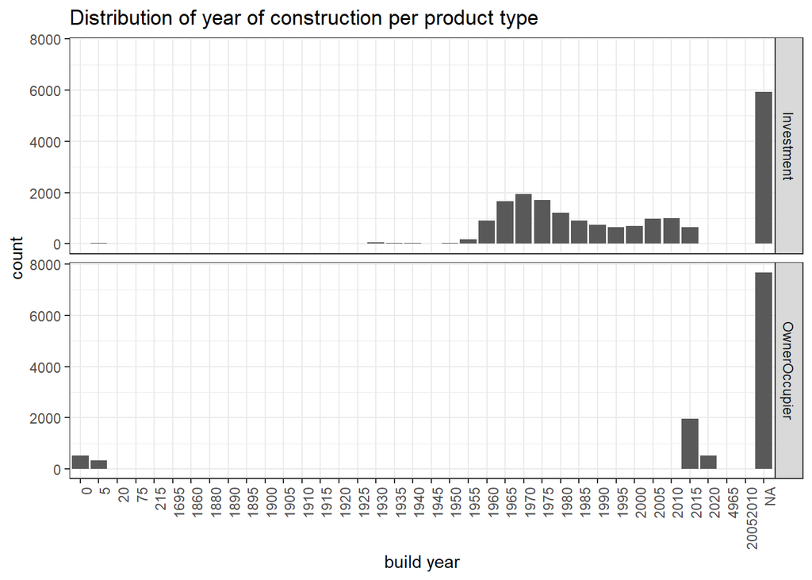

For Investments missings can be changed by the most frequently faced year that is equal to 1970. In case of OwnerOccupier buildings, given the modern years in available data we can assume than nulls mean non-built properties yet. To test this hypothesis we visualize the number of nulls in build_year column versus year of transaction. Unfortunately, this idea was not confirmed by data, conversely, the closer years to nowadays, the more filled cells we have.

Meantime, building the distribution of years difference between creation and purchase witnesses a tendency of buying own properties within two years period from construction. That means we will replace nulls in building years where product_type= OwnerOccupier by value of ‘year’ variable.

```
## .
## 1961 1962 1963 1964 1965 1966 1967 1968 1969 1970 1971 1972 1973 1974 1975
##  297  338  325  315  378  348  384  389  407  418  352  360  333  357  309
## 1976 1977 1978 1979 1980 1981 1982 1983 1984 1985 1986 1987 1988 1989
##  263  260  235  236  226  189  189  185  169  178  131  171  155  155
```

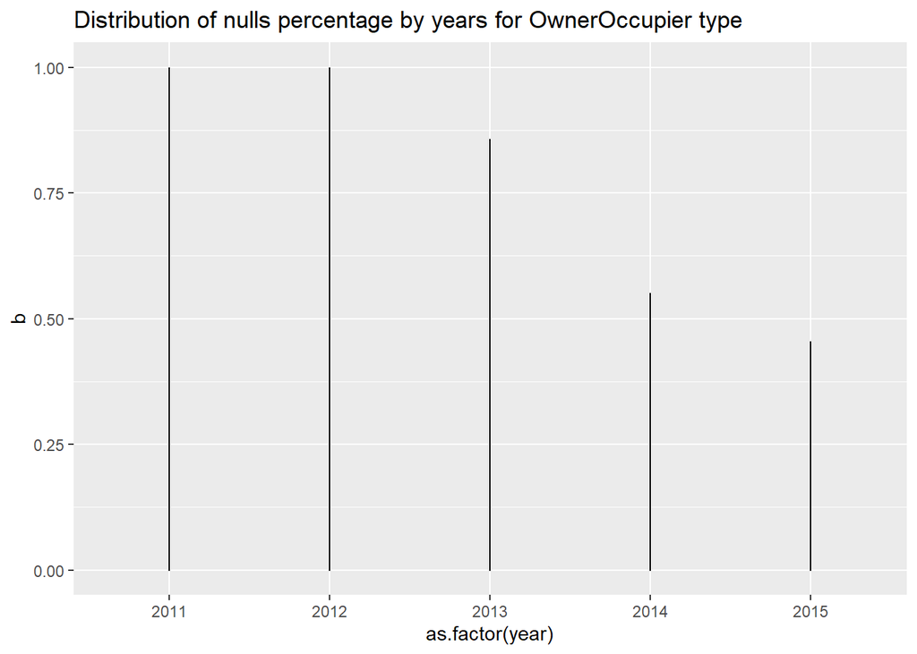

```
## $x
## [1] "build_year"
##
## $y
## [1] "Percent of nulls"
##
## attr(,"class")
## [1] "labels"
```

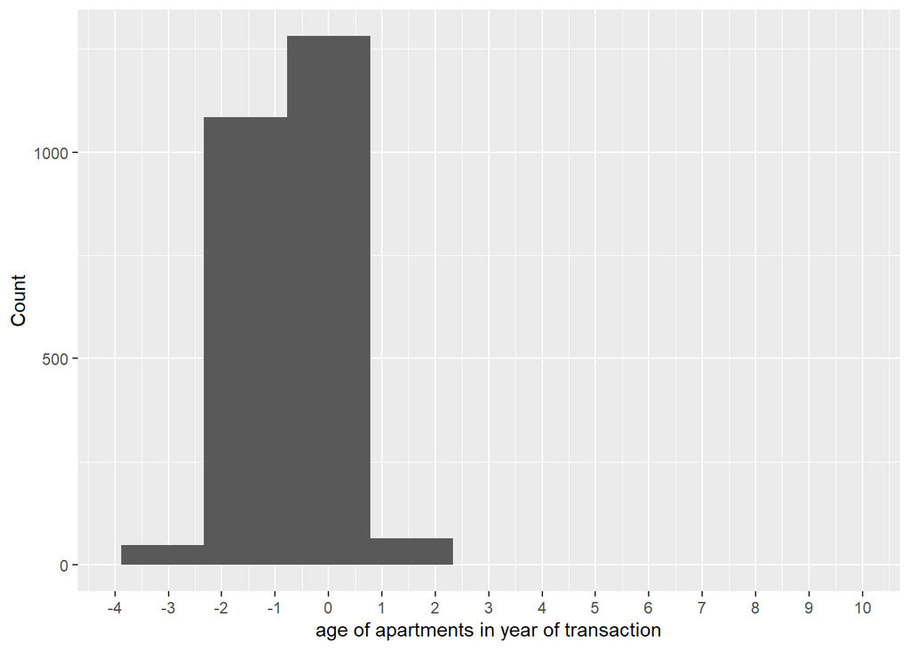

Next, we will look at ‘Full square’ variable, that is full area of property.It does not have missed values but kernel density plot shows presence of extreme values till 5000 sq metres where the most of data is concentrated around 50. It is also confirmed by percentiles meanings - 99% percent of data is less then 134 square metres. As dataset is quite big we will replace outliers by three standart deviations, following the popular approach of treating them. In this case both product types show similar distribution of value and will be processed together.

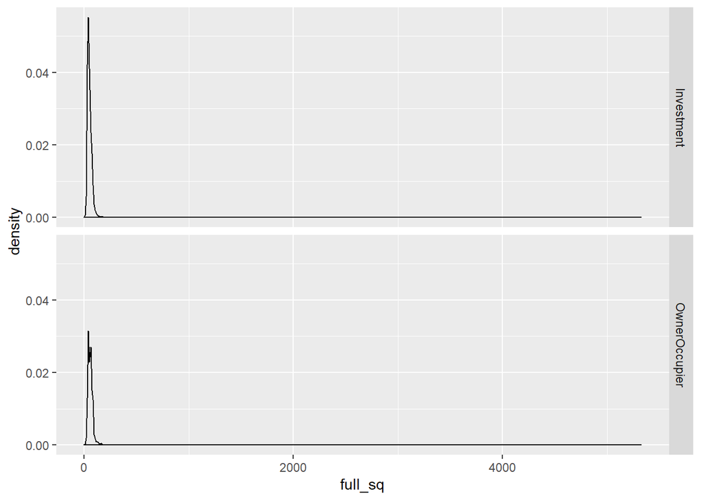

```
##   0%  25%  50%  75%  99% 100%
##    0   38   49   63  134 5326
```

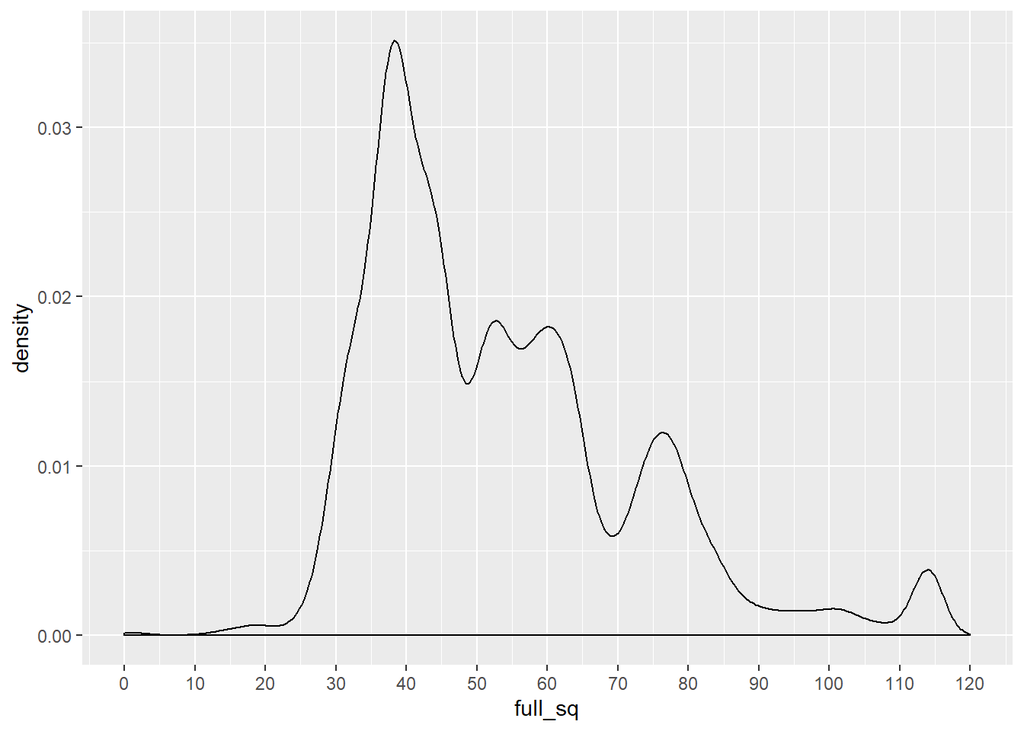

Number of rooms logically also seems to be an important price explonatory variable . It also has more than 25% of missings in column as well as extream values such as zero and 19.Graph below helps us identify 18 observations whose number of rooms are likely to be misspelling and should be replaced. As we suggested, price almost lineary increases with the number of rooms but after 9 the meaning decreases to the level of one-room property and then vary from one level to another without any understandable pattern.

```
## [1] 19
```

```
## [1] 0
```

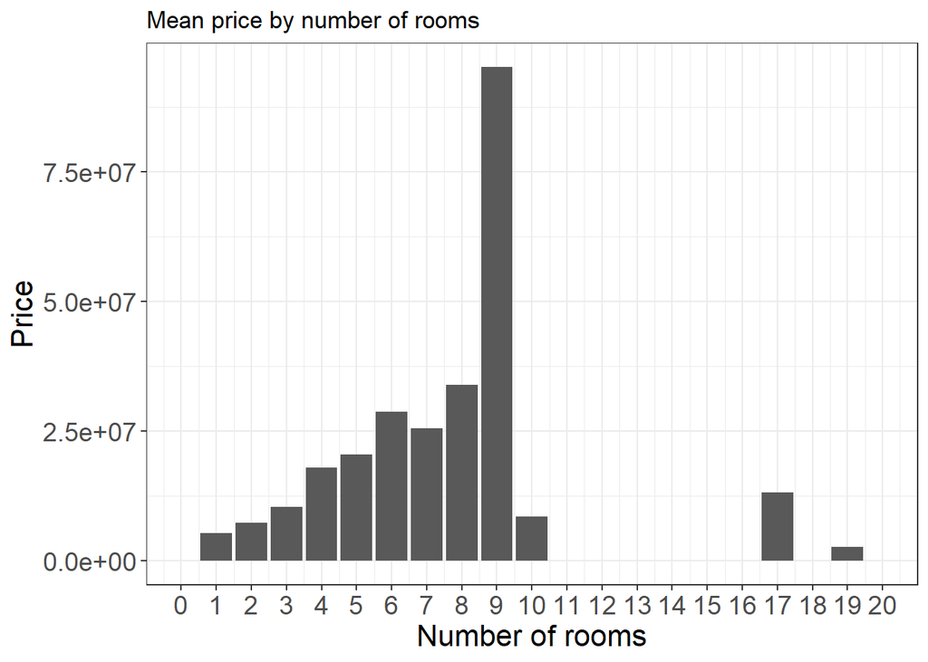

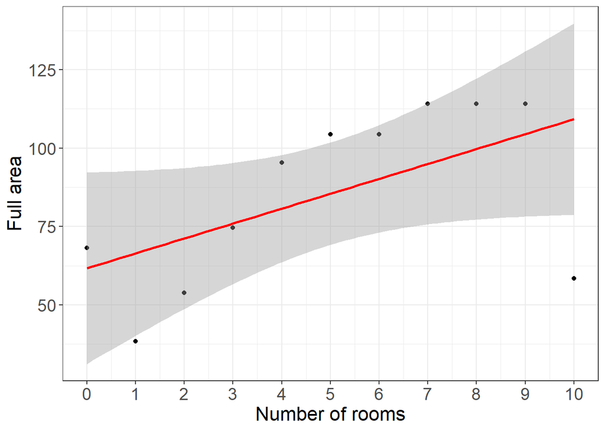

```
##
## Call:
## lm(formula = num_room ~ full_sq, data = data_house %>% filter(!is.na(num_room),
##     num_room > 0, num_room < 10))
##
## Residuals:
##     Min      1Q  Median      3Q     Max
## -2.9817 -0.3630 -0.0533  0.3617  5.0183
##
## Coefficients:
##              Estimate Std. Error t value Pr(>|t|)
## (Intercept) 0.0552758  0.0107230   5.155 2.56e-07 ***
## full_sq     0.0344135  0.0001878 183.282  < 2e-16 ***
## ---
## Signif. codes:  0 '***' 0.001 '**' 0.01 '*' 0.05 '.' 0.1 ' ' 1
##
## Residual standard error: 0.5153 on 20879 degrees of freedom
## Multiple R-squared:  0.6167, Adjusted R-squared:  0.6167
## F-statistic: 3.359e+04 on 1 and 20879 DF,  p-value: < 2.2e-16
```

Then we replace missings and extreme values with calculated linear equitation and round the result to get integer.

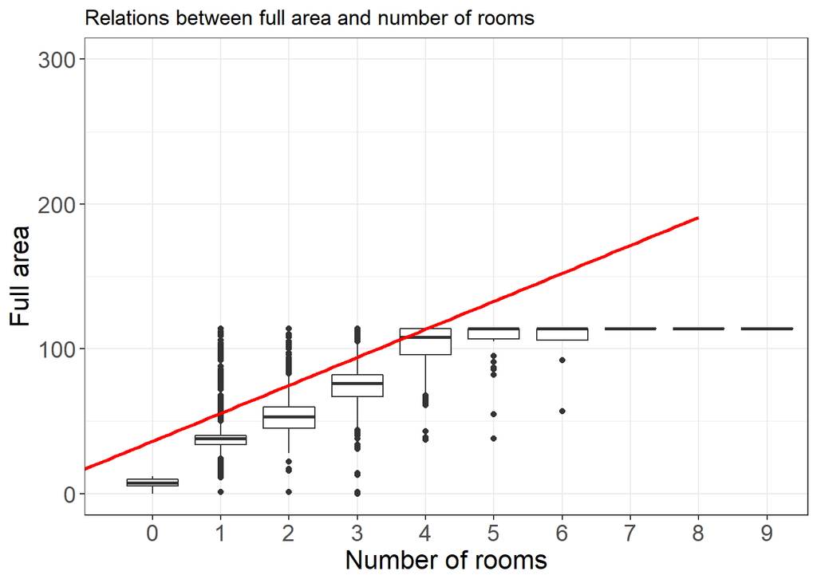

After we filled in gaps in number of rooms, we can easily deal with Life_sq missings and outliers by replacing them with mean of living area in number of rooms bucket. It must enable more precise value than an average of the whole column.

First of all, we put distribution of number of rooms and life_square on graph where we may find out a stead growth of living space over all buckets.

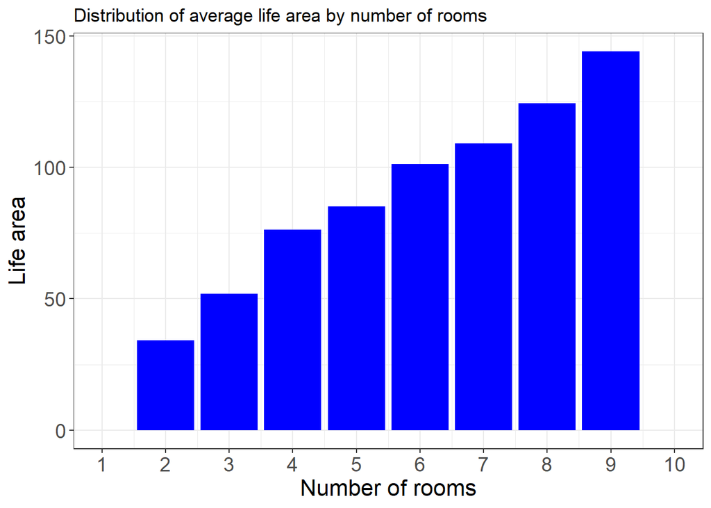

Then we identify outliers using 99.5% quantile. Ultimetaly, they are values more than 123. Together with missings they will be replaced by buckets averages.

```
##   50%   70% 99.5%
##    30    39   123
```

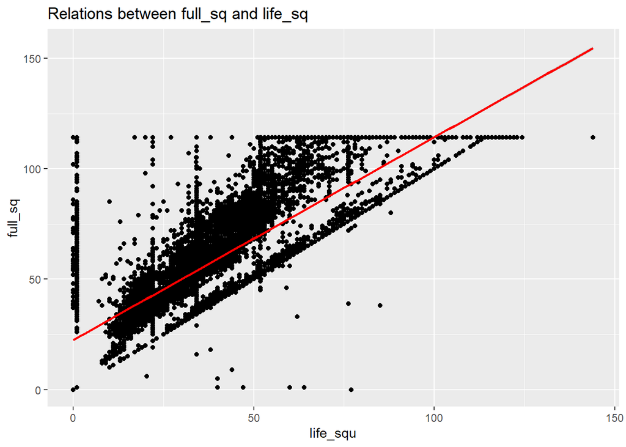

While dealing with kitchen_sq missings and outliers we will use the same technique as for life_sq before.

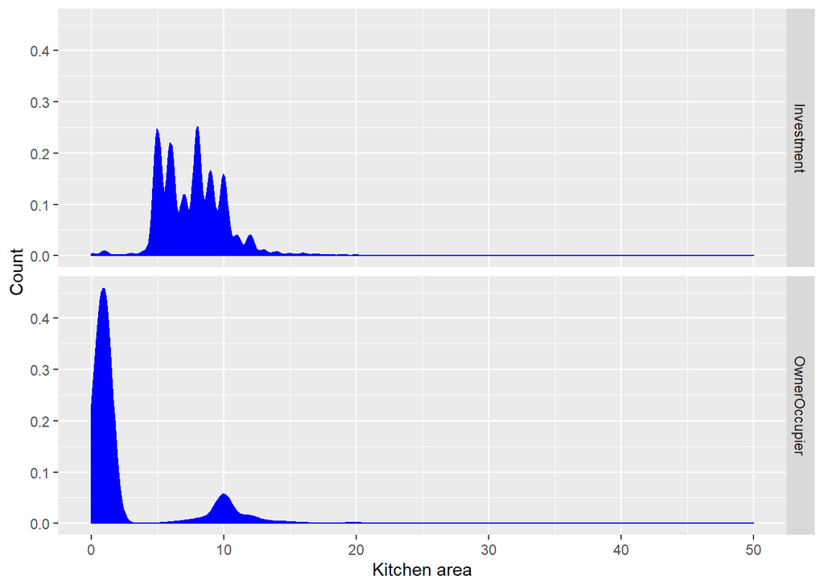

```
##   50%   75% 99.5%
##     6     9    22
```

Next, we process state and material variables describing property condition and wall matrial, respectively. Both probably contribute to pricing. At first, we change their types to factors, because in their case every number mean category. Moreover, boxplot diagram below that reflects distribution of price by state let us suppose state to likely be an ordinal caregorical variable because the median price slightly increases with a state value. Therefore, this variable will be ordered factor.

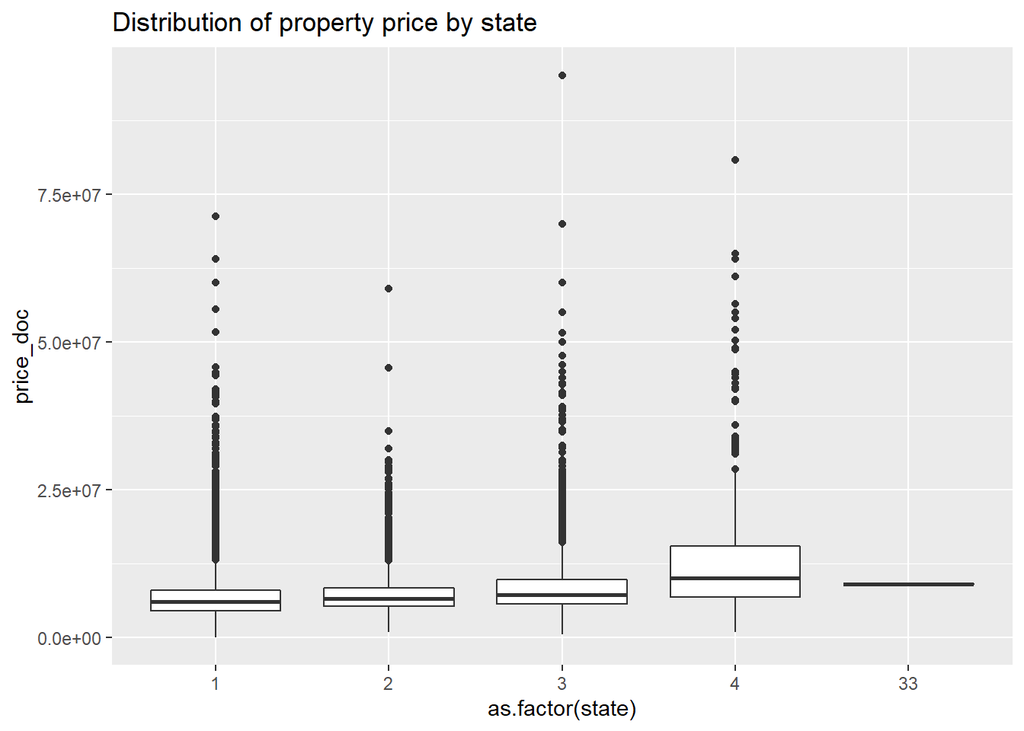

Then we change missings by using the most frequent values. Almost all apartments with OwnerOccupier product type have first state, from which we can conclude that state=1 means new or empty. The weak variation of variable usually means that it will not be included to the range of explanatory variables of final model.

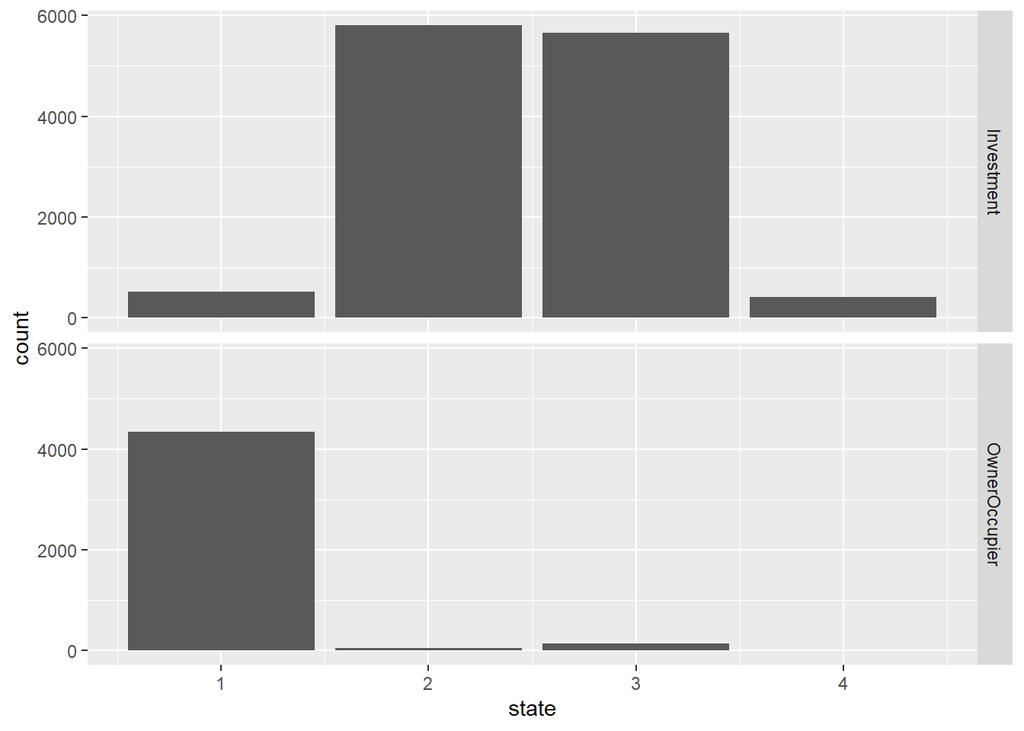

Invested properties do not have state with the significantly higher number of observations as well as distribution of null values on the boxplot below represents median pricelower that this one of other states. That is why, we save null values as a fifth state equal to zero.

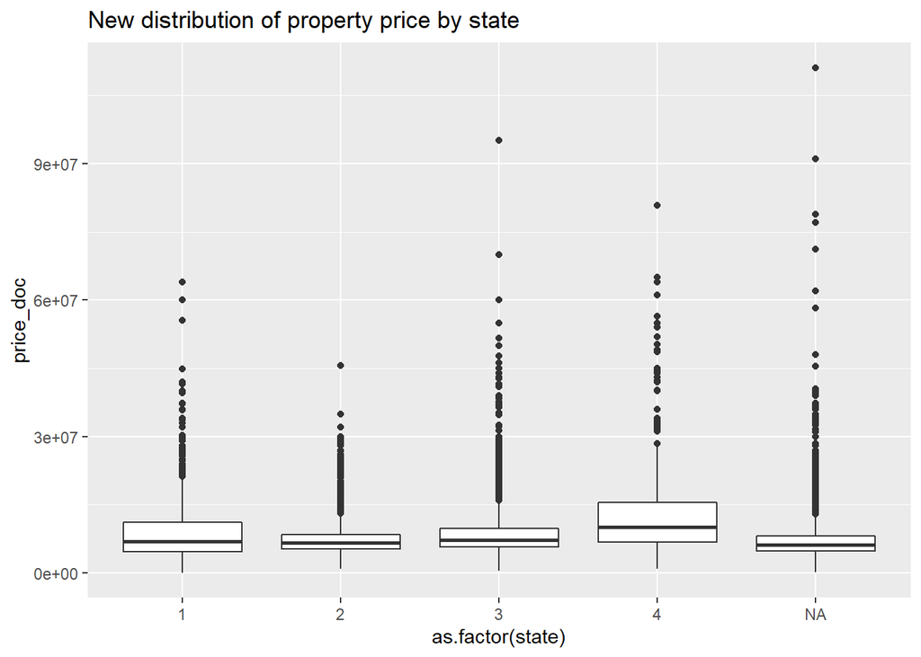

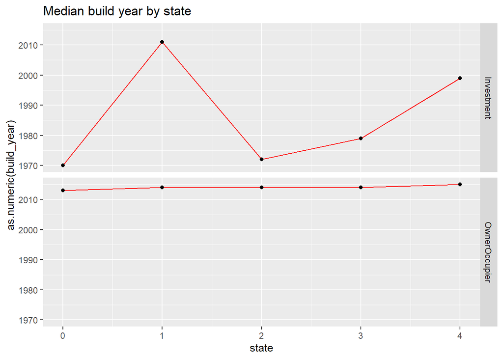

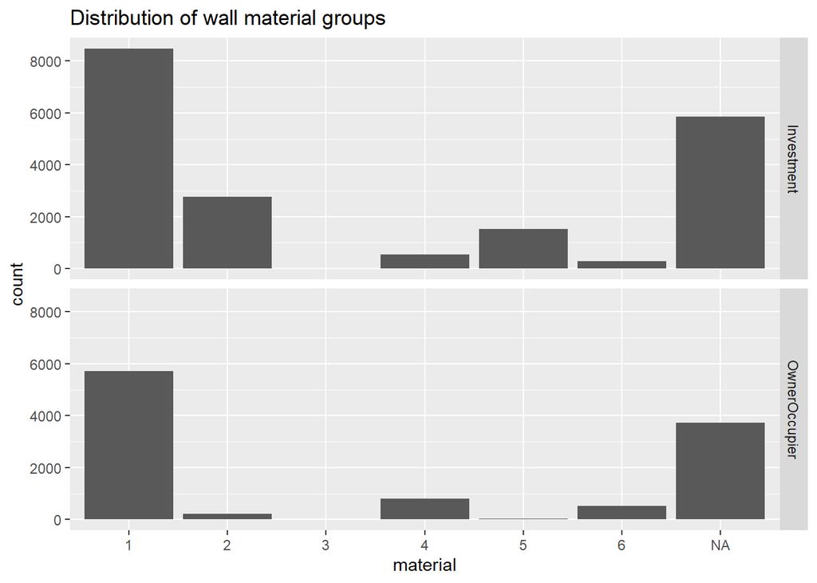

```
## No summary function supplied, defaulting to `mean_se()
```

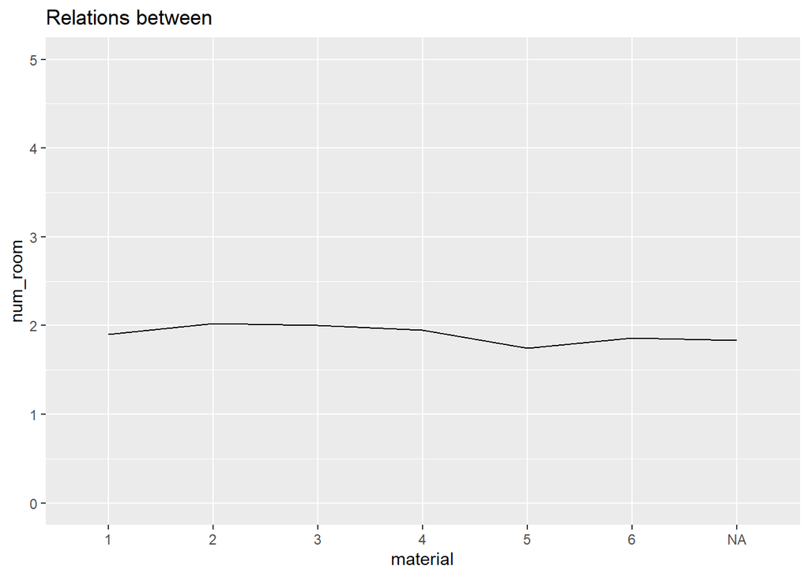

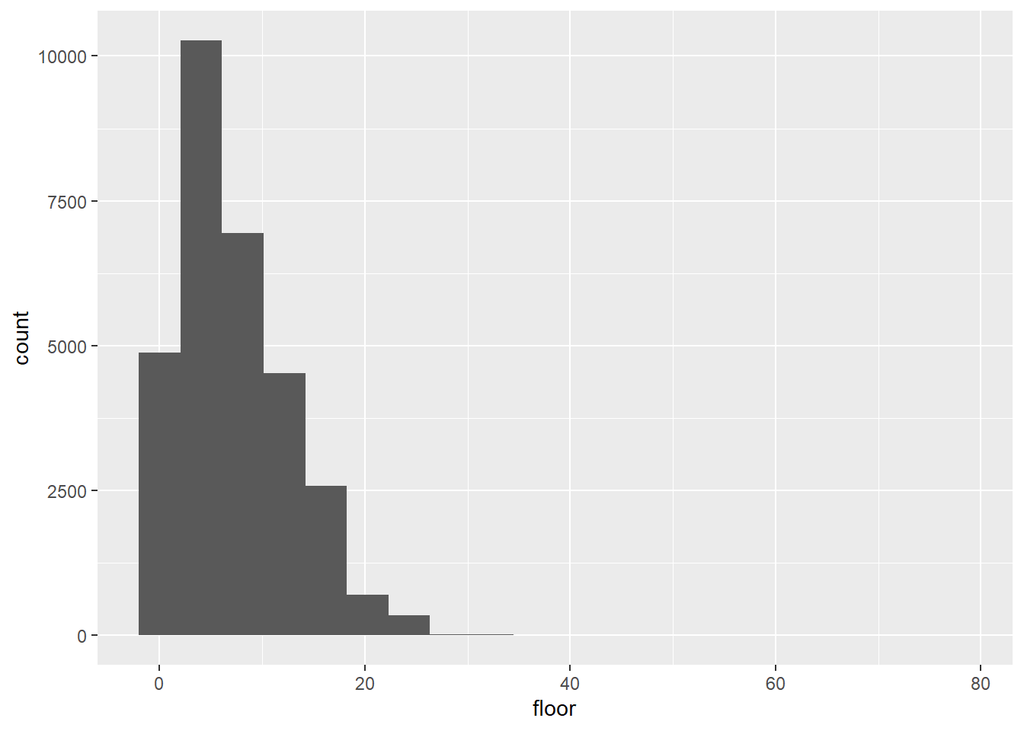

```
## [1] NA
```

Mapping average price over floor no big differences between bins are noticed. However, slight increase of price after floor exceeded 14 is visible.

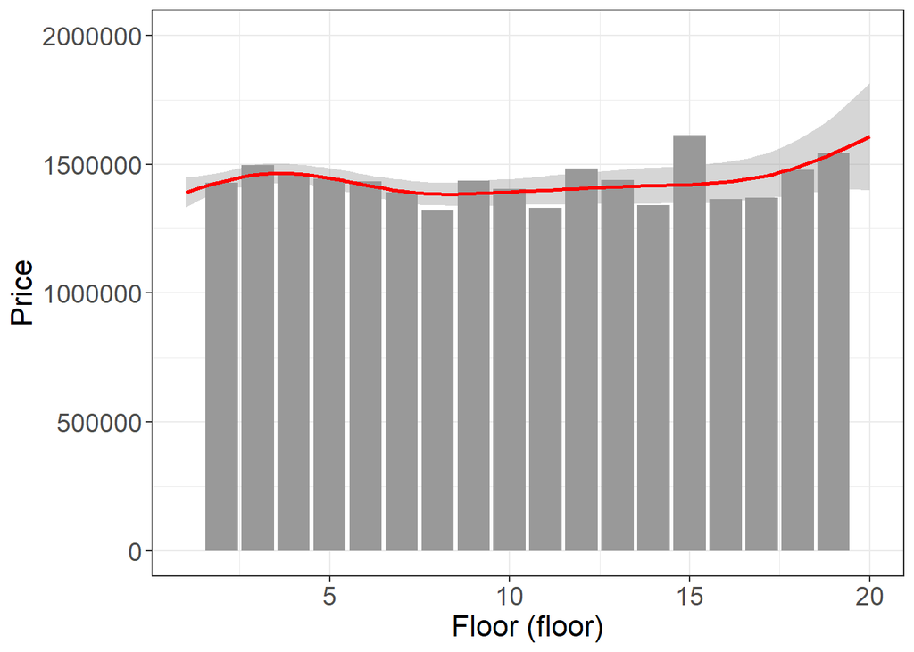

Such property trend says that we can replace missings with mean floor.

```
##
##  factor numeric
##       1       9
```

```
##
## Call:
## lm(formula = price_new ~ ., data = data_house[, property_vars])
##
## Residuals:
##       Min        1Q    Median        3Q       Max
## -0.013337 -0.000987  0.000107  0.000929  0.074995
##
## Coefficients:
##               Estimate Std. Error t value Pr(>|t|)
## (Intercept)  1.296e+00  4.398e-02  29.458  < 2e-16 ***
## full_sq      1.226e-04  1.854e-06  66.099  < 2e-16 ***
## life_squ     1.564e-05  1.622e-06   9.643  < 2e-16 ***
## floor        5.945e-05  3.141e-06  18.929  < 2e-16 ***
## material2    3.226e-04  6.018e-05   5.360 8.38e-08 ***
## material3    1.470e-04  2.732e-03   0.054  0.95709
## material4    1.166e-03  8.074e-05  14.443  < 2e-16 ***
## material5   -1.721e-04  7.566e-05  -2.275  0.02292 *
## material6    1.042e-04  1.015e-04   1.027  0.30450
## build_year  -1.503e-04  2.184e-05  -6.883 5.98e-12 ***
## year_dif    -1.195e-04  2.213e-05  -5.402 6.64e-08 ***
## num_room    -5.316e-04  3.991e-05 -13.320  < 2e-16 ***
## kitch_sq     1.319e-05  4.158e-06   3.171  0.00152 **
## state.L      1.589e-03  9.169e-05  17.329  < 2e-16 ***
## state.Q      1.240e-03  7.832e-05  15.839  < 2e-16 ***
## state.C      6.163e-04  5.832e-05  10.568  < 2e-16 ***
## state^4      9.929e-07  4.316e-05   0.023  0.98164
## ---
## Signif. codes:  0 '***' 0.001 '**' 0.01 '*' 0.05 '.' 0.1 ' ' 1
##
## Residual standard error: 0.002732 on 30454 degrees of freedom
## Multiple R-squared:  0.4049, Adjusted R-squared:  0.4046
## F-statistic:  1295 on 16 and 30454 DF,  p-value: < 2.2e-16
```

```
##
## Call:
## lm(formula = price_new ~ ., data = data_house[data_house$product_type ==
##     "Investment", property_vars])
##
## Residuals:
##       Min        1Q    Median        3Q       Max
## -0.016747 -0.000815  0.000313  0.001087  0.075232
##
## Coefficients:
##               Estimate Std. Error t value Pr(>|t|)
## (Intercept)  1.365e+00  5.925e-02  23.037  < 2e-16 ***
## full_sq      1.061e-04  3.339e-06  31.771  < 2e-16 ***
## life_squ     5.506e-05  3.914e-06  14.067  < 2e-16 ***
## floor        3.079e-05  4.472e-06   6.885 5.94e-12 ***
## material2    4.625e-04  6.905e-05   6.698 2.17e-11 ***
## material4    1.634e-03  1.353e-04  12.078  < 2e-16 ***
## material5   -4.571e-05  7.969e-05  -0.574   0.5662
## material6    4.284e-04  1.776e-04   2.411   0.0159 *
## build_year  -1.851e-04  2.942e-05  -6.292 3.20e-10 ***
## year_dif    -1.522e-04  2.963e-05  -5.136 2.83e-07 ***
## num_room    -6.892e-04  5.334e-05 -12.920  < 2e-16 ***
## kitch_sq     9.919e-05  7.978e-06  12.432  < 2e-16 ***
## state.L      1.711e-03  1.022e-04  16.746  < 2e-16 ***
## state.Q      1.444e-03  8.903e-05  16.217  < 2e-16 ***
## state.C     -1.603e-04  1.030e-04  -1.556   0.1198
## state^4      5.141e-04  7.461e-05   6.890 5.76e-12 ***
## ---
## Signif. codes:  0 '***' 0.001 '**' 0.01 '*' 0.05 '.' 0.1 ' ' 1
##
## Residual standard error: 0.002775 on 19432 degrees of freedom
## Multiple R-squared:  0.4196, Adjusted R-squared:  0.4192
## F-statistic: 936.7 on 15 and 19432 DF,  p-value: < 2.2e-16
```

```
##
## Call:
## lm(formula = price_new ~ ., data = data_house[data_house$product_type ==
##     "OwnerOccupier", property_vars])
##
## Residuals:
##       Min        1Q    Median        3Q       Max
## -0.010437 -0.001137 -0.000314  0.000541  0.047415
##
## Coefficients:
##               Estimate Std. Error t value Pr(>|t|)
## (Intercept)  1.307e+00  6.669e-02  19.601  < 2e-16 ***
## full_sq      1.167e-04  2.562e-06  45.556  < 2e-16 ***
## life_squ     5.993e-06  1.750e-06   3.424  0.00062 ***
## floor        8.696e-05  4.287e-06  20.282  < 2e-16 ***
## material2   -1.111e-03  1.754e-04  -6.334 2.49e-10 ***
## material3    2.928e-04  2.576e-03   0.114  0.90951
## material4    8.105e-04  9.828e-05   8.246  < 2e-16 ***
## material5   -1.928e-03  4.332e-04  -4.450 8.67e-06 ***
## material6    4.130e-05  1.199e-04   0.344  0.73062
## build_year  -1.556e-04  3.311e-05  -4.699 2.64e-06 ***
## year_dif    -9.604e-05  6.380e-05  -1.505  0.13227
## num_room    -4.337e-04  6.403e-05  -6.773 1.32e-11 ***
## kitch_sq    -1.379e-05  5.279e-06  -2.612  0.00902 **
## state.L      1.783e-03  5.490e-04   3.247  0.00117 **
## state.Q      4.176e-04  5.113e-04   0.817  0.41408
## state.C      2.235e-04  3.072e-04   0.728  0.46688
## state^4      2.575e-04  3.219e-04   0.800  0.42369
## ---
## Signif. codes:  0 '***' 0.001 '**' 0.01 '*' 0.05 '.' 0.1 ' ' 1
##
## Residual standard error: 0.002575 on 11006 degrees of freedom
## Multiple R-squared:  0.4124, Adjusted R-squared:  0.4116
## F-statistic: 482.9 on 16 and 11006 DF,  p-value: < 2.2e-16
```

Anyway, the next question is how external variables will improve this result. Analysis of multicollinearityof variables and distribution residuals is not being carried out on this stage because this model is not final.

# Analysis of variables describing region

Now we approach second group of variables that associated with area around the property. This group contains more than 200 parametres but we will check only those related to accessability of different facilities and leisure spots as well as estimated distances to public transport.

```
##                if_missed
## pr_type         FALSE TRUE
##   Investment      241   43
##   OwnerOccupier   241   43
```

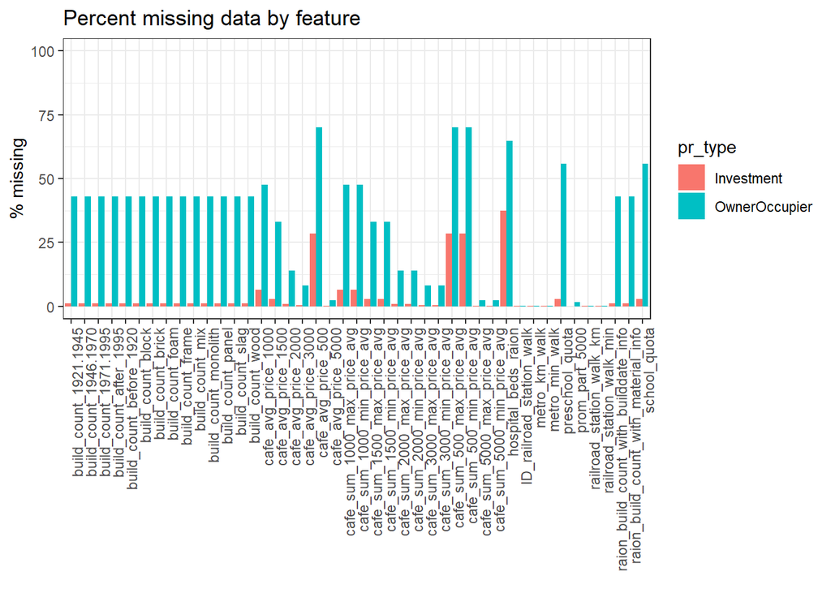

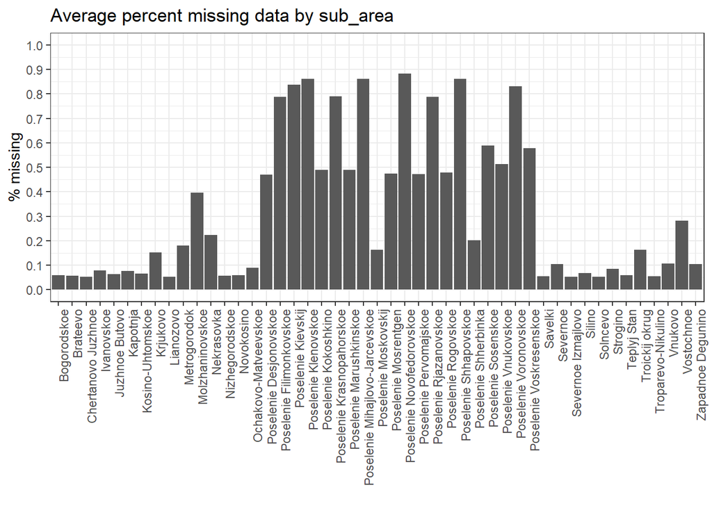

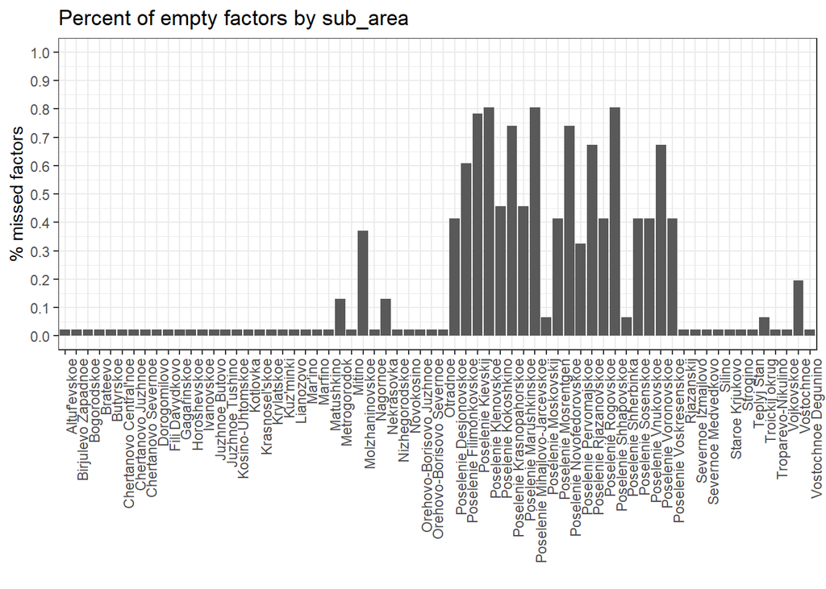

```
## [1] 25309   284
```

Next, the rest of missings will be changed by mean value in the districts. While we do not know if the region statistic was updated with the time, the hystoric dynamic of average value calculated for each column shows that mean does not change over time, that suggests the data was collected once. Although it is likely decrease explanatory ability of variables to explain price, it allows us to replace missings without considering ‘year’ variable.

[output not shown]

After all transformations we still have 12 factors with missings. They are linked to the average price of cafes, the number of available places in hospitals and schools around, that seem potentially important for explaining price.

```
##                if_missed
## pr_type         FALSE TRUE
##   Investment      272   12
##   OwnerOccupier   275    9
```